# A Comparison of Filters for Reducing False Positive Indels in Low Complexity Regions Regions

Mike Huang

## 2 Methods

### 2.1 Filters Compared (BED files)

1. *Low Complexity Region filter* generated by the original mDUST algorithm used in BLAST. A BED file of the LCRs for GChR37 can be found at https://github.com/lh3/varcmp/raw/master/scripts/LCR-hs37d5.bed.gz
2. *Tandem Repeat filter for repeats =>5* generated by Jeanie Lim. The BED file is named Duke800_PatternsRepeat5 and can be found in the supplementary files.
3. *Tandem Repeat filter for repeats =>10* generated by Jeanie Lim. The BED file is named Duke800_PatternsRepeat10 and can be found in the supplementary files.
4. *Tandem Repeat filter for repeats =<12* generated by Repeat Masker. The BED file of the Repeat Masker regions for hg19 is contained within chromTrf.tar.gz and can be found at http://hgdownload.cse.ucsc.edu/goldenPath/hg19/bigZips/

### 2.2 Dataset

Trio Samples: CHH1676, CHH1677, CHH1678  
Filter: pass_filtered

### 2.3 Reference Indel Databases:

1. dbsnp_135.b37.vcf.gz
2. ExAC.r0.3.1.sites.vep.vcf.gz

### 2.4 Filtering BED regions from VCF file

VCF files were filtered with the respective BED regions using the following command:

`vcftools --gzvcf trio.vcf.gz --out trio_outputname --keep-only-indels --recode --exclude-bed filter.bed`

### 2.5 Validation

Validation was performed by comparison with reference variant databases, dbSNP and ExAC, which is considered as “ground truth.” This was performed by intersecting the filtered VCF file with the reference VCF. The intersection was performed with the following command:

`bcftools stats trio.vcf.gz reference.vcf.gz`

### 2.6 Allele Frequency Analysis

Allele Frequency was analyzed from the ExAC population and compared between *LCR indels found in ExAC* vs *non LCR indels found in ExAC*. To find these two corresponding VCFs, the intersections were made with the following command:

`bcftools isec -p outputfolder trio_indels.vcf.gz ExAC.r0.3.1.sites.vep.vcf.gz`

## 3 Results

### 3.1 Remaining variants after filtering

[output not shown]

### 3.2 Validation of LCR filtered indels with dbSNP

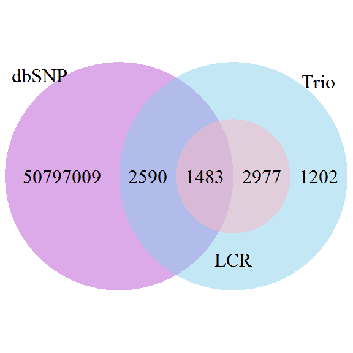

|  | Indels |
| --- | --- |
| $Trio \cap LCR$ | 4460 |
| $Trio \setminus LCR$ | 3792 |
| $dbSNP \cap Trio \cap LCR$ | 1483 |
| $dbSNP \cap Trio \setminus LCR$ | 2590 |

|  | TP | FP | Precision | Sensitivity |
| --- | --- | --- | --- | --- |
| Before LCR filter | 4073 | 4179 | 4073/8252(49%) | 4073/4073(100%) |
| After LCR filter | 2590 | 1202 | 2590/3792(68%) | 2590/4073(63%) |

$Precision = \frac{TP}{TP+FP}$

An ideal filter should exclude false positives while keeping true positives. In this case, 1483/4460(33%) of indels in LCR regions are found in dbSNP vs 2590/3792(68%) of indels in non-LCR regions are found in dbSNP. Thus if dbSNP is a gold standard to determine true positives, 33% of the indels filtered by LCR are true positives. This is a non-trivial amount. However, it raised the precision from 49% to 68%.

However, dbSNP is not without inaccuracies. dbSNP is estimated to have a 15-17% false positive rate[1].

### 3.3 Validation of LCR filtered indels with ExAC

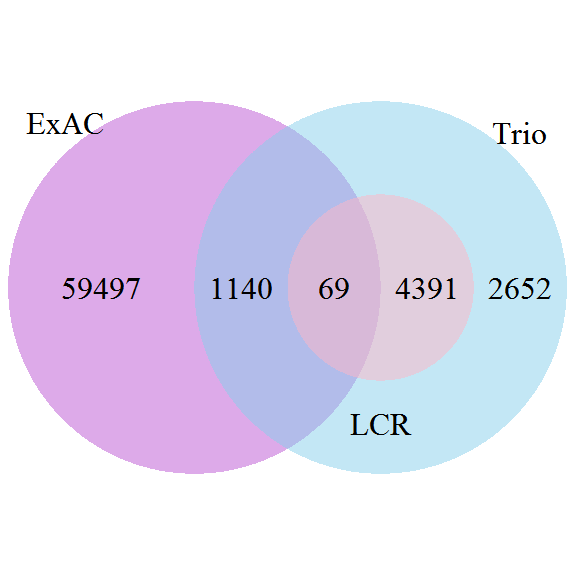

| Intersection | Indels |
| --- | --- |
| $Trio \cap LCR$ | 4460 |
| $Trio \setminus LCR$ | 3792 |
| $ExAC \cap Trio \cap LCR$ | 69 |
| $ExAC \cap Trio \setminus LCR$ | 1140 |

|  | TP | FP | Precision | Sensitivty |
| --- | --- | --- | --- | --- |
| Before LCR filter | 1209 | 7043 | 1209/8252(15%) | 1209/1209(100%) |
| After LCR filter | 1140 | 2652 | 1140/3792(30%) | 1140/1209(94%) |

69/4460(1.5%) of indels in LCR regions are found in ExAC vs 1140/3792(30%) of indels in non-LCR regions are found in ExAC. Thus, if ExAC was considered the gold standard, LCR filters very few TP at 1.5% while doubling the precision from 15% to 30%.

### 3.4 Allele Frequency Analysis

Perhaps the 1.5% of indels in LCR regions that are found in ExAC may be due to errors in ExAC itself. Low allele frequencies have been shown to lead to lowered confirmation of SNPs in public databases[1]. To determine the likelihood of errors in the indels found in ExAC that intersects with LCR, the distribtion of allele frequencies was determined between LCR indels in ExAC and non LCR indels in ExAC.

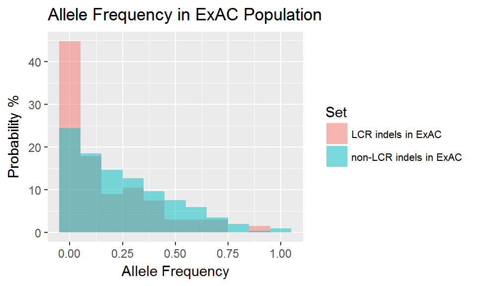

## 5 References

1. Mitchell, A. A., Zwick, M. E., Chakravarti, A., & Cutler, D. J. (2004). Discrepancies in dbSNP confirmation rates and allele frequency distributions from varying genotyping error rates and patterns. Bioinformatics, 20(7), 1022-1032. doi:10.1093/bioinformatics/bth034